# PEC1 - Metadatos del dataset

Irene Martínez Serrano

1/11/2024

# Selección de datos

Brevemente, en el [repositorio metaboData de Github](https://github.com/nutrimetabolomics/metaboData/) hemos seleccionado específicamente el conjunto de datos 2024-fobitools-UseCase_1. Se trata de un estudio de metabolómica global que contiene tres archivos separados:

- **Datos** -> 1541 variables, 45 muestras
- **Metadata** -> 45 filas, dos columnas (nombre de la muestra, nombre del grupo)
- Adicional: **Nombre de metabolitos** -> 1541 filas, 3 columnas (nombre original, ID de PubChem y ID de KEGG)

Aunque estos datos también se encuentran en la interfaz de [*MetabolomicsWorkbench*](https://www.metabolomicsworkbench.org/databases/index.php), decidimos continuar con los datos desCargados desde **Github** puesto que estos ya estan pre-procesados. Tal y como se explica en la descripción del estudio, la parte analítica del estudio consiste en dos métodos diferentes que luego se recogen en un solo dataset puesto que son complementarios.

# Especificaciones

- *Baseline*
- *Crawberry*
- *Apple*

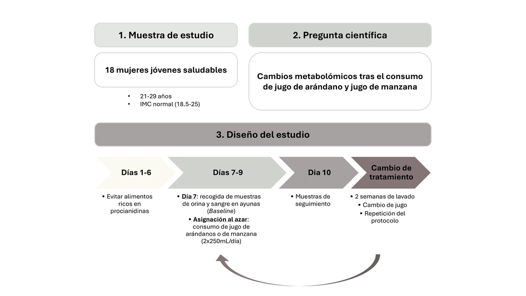

*Figura 2*. Visión general de la recogida de datos del dataset escogido.

Los metadatos en cuestión son:

|  | Treatment |
| --- | --- |
| b1 | Baseline |
| b10 | Baseline |
| b11 | Baseline |
| b12 | Baseline |
| b13 | Baseline |
| b14 | Baseline |
| b15 | Baseline |
| b16 | Baseline |
| b17 | Baseline |
| b2 | Baseline |
| b4 | Baseline |
| b6 | Baseline |
| b7 | Baseline |
| b8 | Baseline |
| b9 | Baseline |
| a1 | Apple |
| a10 | Apple |
| a11 | Apple |
| a12 | Apple |
| a13 | Apple |
| a14 | Apple |
| a15 | Apple |
| a16 | Apple |
| a17 | Apple |
| a2 | Apple |
| a4 | Apple |
| a6 | Apple |
| a7 | Apple |
| a8 | Apple |
| a9 | Apple |
| c1 | Cranberry |
| c10 | Cranberry |
| c11 | Cranberry |
| c12 | Cranberry |
| c13 | Cranberry |
| c14 | Cranberry |
| c15 | Cranberry |
| c16 | Cranberry |
| c17 | Cranberry |
| c2 | Cranberry |
| c4 | Cranberry |
| c6 | Cranberry |
| c7 | Cranberry |
| c8 | Cranberry |
| c9 | Cranberry |